# Biostat 212a Homework 5

Due Mar 16, 2024 @ 11:59PM

Author

Nathaniel Boyle and 006525153

Published

March 13, 2025

## 1 ISL Exercise 9.7.1 (10pts)

### 1.1 1. Hyperplanes in two dimensions.

#### 1.1.1 part a. and part b.

Sketch the hyperplane $1+3X_1−X_2=0$. Indicate the set of points for which $1+3X1−X2>0$ as well as the set of points for which $1+3X_1−X_2<0$.

On the same plot, sketch the hyperplane $−2+X_1+2X_2=0$ Indicate the set of points for which $−2+X_1+2X_2>0$ as well as the set of points for which $−2+X_1+2X_2<0$

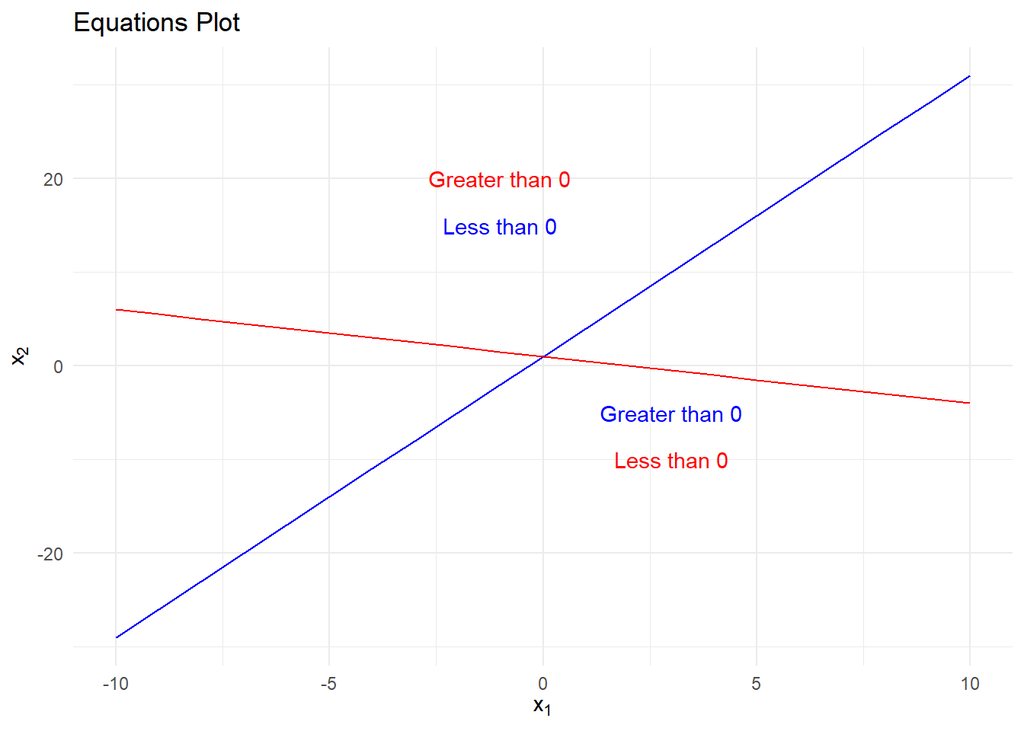

```r
library(ggplot2)

# Define the data for the two equations
x1 <- -10:10
x2 <- 1 + 3 * x1
x3 <- 1 - x1 / 2

# Create a data frame for ggplot
df <- data.frame(x1 = x1, x2 = x2, x3 = x3)

# Plot the graph using ggplot2
ggplot(df, aes(x = x1)) +
  # Plot the first line (blue)
  geom_line(aes(y = x2), color = "blue") +

  # Annotate text for the blue line
  annotate("text", x = 3, y = -5, label = "Greater than 0", color = "blue") +
  annotate("text", x = -1, y = 15, label = "Less than 0", color = "blue") +

  # Plot the second line (red)
  geom_line(aes(y = x3), color = "red") +

  # Annotate text for the red line
  annotate("text", x = 3, y = -10, label = "Less than 0", color = "red") +
  annotate("text", x = -1, y = 20, label = "Greater than 0", color = "red") +

  # Add the legend with LaTeX formatting
  scale_color_manual(
    values = c("blue", "red"),
    labels = c(
      expression(1 + 3 * x[1] - x[2] == 0),
      expression(-2 + x[1] + 2 * x[2] == 0)
    )
  ) +

  # Add labels and title
  labs(
    title = "Equations Plot",
    x = expression(x[1]),
    y = expression(x[2])
  ) +

  # Set theme for better appearance
  theme_minimal() +
  theme(legend.position = "right")
```

## 2 ISL Exercise 9.7.2 (10pts)

We have seen that in $p = 2$ dimensions, a linear decision boundary takes the form $β_0+β_1X_1+β_2X_2 = 0$. We now investigate a non-linear decision boundary.

### 2.1 2.a and 2.b

Sketch the curve $(1 + X_1)^2 + (2 − X2)^2 = 4$. On your sketch, indicate the set of points for which $(1 + X1)^2 + (2 − X2)^2 > 4$, as well as the set of points for which $(1 + X1)^2 + (2 − X2)^2 ≤ 4$

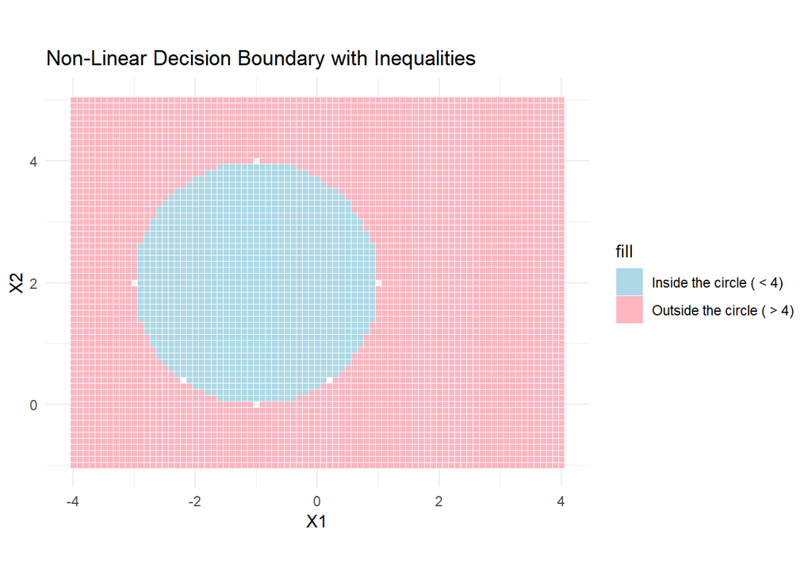

```r
# Load ggplot2 library
library(ggplot2)

# Define the equation of the circle (1 + X1)^2 + (2 - X2)^2 = 4
# The center is (1, 2) and the radius is 2

radius <- 2
center_x <- 1
center_y <- 2

# Generate points to plot the circle
theta <- seq(0, 2*pi, length.out = 100)  # Angle sequence
x1 <- center_x + radius * cos(theta)  # X1 coordinates
x2 <- center_y + radius * sin(theta)  # X2 coordinates

# Create a data frame for ggplot
circle_data <- data.frame(X1 = x1, X2 = x2)

# Create a grid of points to evaluate the inequality
grid_x1 <- seq(-4, 4, by = 0.1)
grid_x2 <- seq(-1, 5, by = 0.1)
grid <- expand.grid(X1 = grid_x1, X2 = grid_x2)

# Evaluate the inequality (1 + X1)^2 + (2 - X2)^2 at each point
grid$distance_squared <- (1 + grid$X1)^2 + (2 - grid$X2)^2

# Plot the circle using ggplot
ggplot() +
  # Shading for (1 + X1)^2 + (2 - X2)^2 < 4 (inside the circle)
  geom_tile(data = subset(grid, distance_squared < 4),
            aes(x = X1, y = X2, fill = "Inside the circle ( < 4)"),
            color = "white", width = 0.1, height = 0.1) +

  # Shading for (1 + X1)^2 + (2 - X2)^2 > 4 (outside the circle)
  geom_tile(data = subset(grid, distance_squared > 4),
            aes(x = X1, y = X2, fill = "Outside the circle ( > 4)"),
            color = "white", width = 0.1, height = 0.1) +


  # Add labels and title
  labs(x = "X1", y = "X2",
       title = "Non-Linear Decision Boundary with Inequalities") +

  # Theme and legend customization
  theme_minimal() +
  scale_fill_manual(
    values = c("Inside the circle ( < 4)" = "lightblue",
               "Outside the circle ( > 4)" = "lightpink")) +

  coord_fixed(ratio = 1) +  # Ensure equal aspect ratio
  theme(legend.position = "right")  # Place legend to the right
```

### 2.2 2.c

Suppose that a classier assigns an observation to the blue class if $(1 + X1)2 + (2 − X2)2 > 4$, and to the red class otherwise. To what class is the observation $(0, 0)$ classified? $(−1, 1)$? $(2, 2)$? $(3, 8)$?

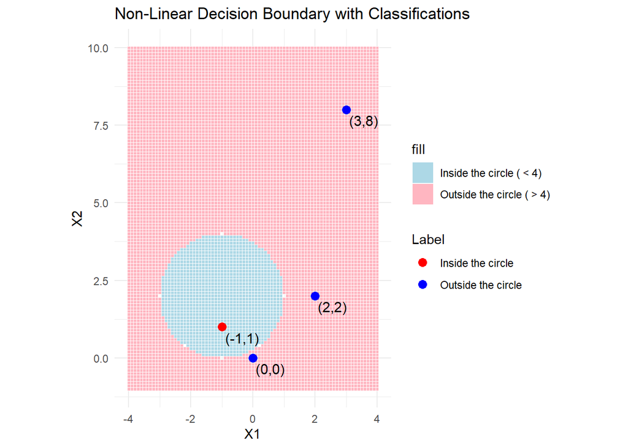

```r
# Load ggplot2 library
library(ggplot2)

# Define the equation of the circle (1 + X1)^2 + (2 - X2)^2 = 4
# The center is (1, 2) and the radius is 2

radius <- 2
center_x <- 1
center_y <- 2

# Generate points to plot the circle
theta <- seq(0, 2*pi, length.out = 100)  # Angle sequence
x1 <- center_x + radius * cos(theta)  # X1 coordinates
x2 <- center_y + radius * sin(theta)  # X2 coordinates

# Create a data frame for ggplot
circle_data <- data.frame(X1 = x1, X2 = x2)

# Create a grid of points to evaluate the inequality
grid_x1 <- seq(-4, 4, by = 0.1)
grid_x2 <- seq(-1, 10, by = 0.1)
grid <- expand.grid(X1 = grid_x1, X2 = grid_x2)

# Evaluate the inequality (1 + X1)^2 + (2 - X2)^2 at each point
grid$distance_squared <- (1 + grid$X1)^2 + (2 - grid$X2)^2

# Define the observations to classify
observations <- data.frame(
  X1 = c(0, -1, 2, 3),
  X2 = c(0, 1, 2, 8),
  Label = c("Outside the circle", "Inside the circle",
            "Outside the circle", "Outside the circle")
)

# Plot the circle using ggplot2
ggplot() +
  # Shading for (1 + X1)^2 + (2 - X2)^2 < 4 (inside the circle)
  geom_tile(data = subset(grid, distance_squared < 4),
            aes(x = X1, y = X2, fill = "Inside the circle ( < 4)"),
            color = "white", width = 0.1, height = 0.1) +

  # Shading for (1 + X1)^2 + (2 - X2)^2 > 4 (outside the circle)
  geom_tile(data = subset(grid, distance_squared > 4),
            aes(x = X1, y = X2, fill = "Outside the circle ( > 4)"),
            color = "white", width = 0.1, height = 0.1) +

  # Plot the observations with classifications
  geom_point(data = observations,
             aes(x = X1, y = X2, color = Label), size = 3) +

  # Add coordinates as text labels next to the points
  geom_text(data = observations,
            aes(x = X1, y = X2, label = paste("(", X1, ",", X2, ")", sep = "")),
            vjust = 1.5, hjust = -0.1, size = 4, color = "black") +

  # Add labels and title
  labs(x = "X1", y = "X2",
       title = "Non-Linear Decision Boundary with Classifications") +

  # Theme and legend customization
  theme_minimal() +

  scale_fill_manual(
    values = c("Inside the circle ( < 4)" = "lightblue",
               "Outside the circle ( > 4)" = "lightpink")) +
  scale_color_manual(
    values = c("Outside the circle" = "blue", "Inside the circle" = "red")) +

  coord_fixed(ratio = 1) +  # Ensure equal aspect ratio
  theme(legend.position = "right")  # Place legend to the right
```

### 2.3 2.d

Argue that while the decision boundary in (c) is not linear in terms of $X_1$ and $X_2$, it is linear in terms of $X_1$, $X_1^2$ , $X_2$, and$X_2^2$.

The decision boundary in the given problem is represented by the equation:
$$(1+X_1)^2 + (2 - X_2)^2 = 4$$
Although this represents a circle, if we transform the variables we can express this boundary in a linear form.

Expanding our squares to represent our boundary in terms of $X_1$, $X_1^2$ , $X_2$, and $X_2^2$:

$$(1+2X_1 +X_1^2 )+(4 − 4X_2 + X_2^2)=4$$

Simplify:

$$2X_1 − 4X_2 + X_1^2 + X_2^2 = −1$$

We can now transform our boundary terms into new, Linear terms of $Z_n$, where n is an integer that represents a new variable transformation for any $X_n$.

$$Z_1 = X_1$$
$$Z_2 = X_1^2$$
$$Z_3 = X_2$$
$$Z_4 = X_2^2$$

Now our decision boundary becomes:

$$2Z_1 − 4Z_3 + Z_2 + Z_4 = −1$$
This *is* a linear equation. Therefore our decision boundary is linear in terms of $X_1$, $X_1^2$ , $X_2$, and$X_2^2$ when we transform them to $Z_n$ This is the core of what SVMs do with non-linear boundaries. Transforming the data into higher-dimensional feature space allows models to apply linear classifiers to non-linear equations.

## 3 Support vector machines (SVMs) on the `Carseats` data set (30pts)

Follow the machine learning workflow to train support vector classifier (same as SVM with linear kernel), SVM with polynomial kernel (tune the degree and regularization parameter $C$), and SVM with radial kernel (tune the scale parameter $\gamma$ and regularization parameter $C$) for classifying `Sales<=8` versus `Sales>8`. Use the same seed as in your HW4 for the initial test/train split and compare the final test AUC and accuracy to those methods you tried in HW4.

```r
# Check if packages are installed and install them if not
if (!requireNamespace("ISLR", quietly = TRUE)) {
  install.packages("ISLR", repos = "https://cloud.r-project.org/")
}
if (!requireNamespace("e1071", quietly = TRUE)) {
  install.packages("e1071", repos = "https://cloud.r-project.org/")
}
if (!requireNamespace("caret", quietly = TRUE)) {
  install.packages("caret", repos = "https://cloud.r-project.org/")
}

# Load the libraries
library(ISLR)
library(e1071)  # SVM implementation
library(caret)   # For model training and tuning
# Load the carseats dataset
data("Carseats")

# Create a binary target variable: Sales <= 8 versus Sales > 8
Carseats$SalesBinary <- ifelse(Carseats$Sales <= 8, 0, 1)

# Create a training and testing split
set.seed(123)
trainIndex <- createDataPartition(Carseats$SalesBinary, p = 0.7, list = FALSE)
trainData <- Carseats[trainIndex, ]
testData <- Carseats[-trainIndex, ]

# Standardize the training and testing sets
preProcValues <- preProcess(trainData[, -c(1, 2, 11)], method = c("center",
                                                                  "scale"))
trainDataScaled <- predict(preProcValues, trainData[, -c(1, 2, 11)])
testDataScaled <- predict(preProcValues, testData[, -c(1, 2, 11)])

# Add the target variable back
trainDataScaled$SalesBinary <- trainData$SalesBinary
testDataScaled$SalesBinary <- testData$SalesBinary

# Ensure that SalesBinary is a factor before making predictions
trainDataScaled$SalesBinary <- factor(trainDataScaled$SalesBinary,
                                      levels = c(0, 1))
testDataScaled$SalesBinary <- factor(testDataScaled$SalesBinary,
                                     levels = c(0, 1))

# SVM with linear kernel
svm_linear <- svm(SalesBinary ~ .,
                  data = trainDataScaled, kernel = "linear")

# Make predictions
pred_linear <- predict(svm_linear, testDataScaled)

# Convert the predicted values to factors (for linear kernel)
pred_linear_factor <- factor(pred_linear, levels = c(0, 1))

# Evaluate the model for linear kernel
confusionMatrix(pred_linear_factor, testDataScaled$SalesBinary)
```

```
Confusion Matrix and Statistics

          Reference
Prediction  0  1
         0 62 12
         1  9 37

               Accuracy : 0.825
                 95% CI : (0.745, 0.8883)
    No Information Rate : 0.5917
    P-Value [Acc > NIR] : 3.691e-08

                  Kappa : 0.6344

 Mcnemar's Test P-Value : 0.6625

            Sensitivity : 0.8732
            Specificity : 0.7551
         Pos Pred Value : 0.8378
         Neg Pred Value : 0.8043
             Prevalence : 0.5917
         Detection Rate : 0.5167
   Detection Prevalence : 0.6167
      Balanced Accuracy : 0.8142

       'Positive' Class : 0
```

```r
# Tune SVM with polynomial kernel
tune_poly <- tune(svm, SalesBinary ~ ., data = trainDataScaled,
                  kernel = "polynomial",
                  ranges = list(degree = 2:4, cost = 10^(-1:1)))

# Get the best model
svm_poly <- tune_poly$best.model

# Make predictions for the polynomial kernel
pred_poly <- predict(svm_poly, testDataScaled)

# Convert the predicted values to factors (for polynomial kernel)
pred_poly_factor <- factor(pred_poly, levels = c(0, 1))

# Evaluate the model for polynomial kernel
confusionMatrix(pred_poly_factor, testDataScaled$SalesBinary)
```

```
Confusion Matrix and Statistics

          Reference
Prediction  0  1
         0 58 13
         1 13 36

               Accuracy : 0.7833
                 95% CI : (0.6989, 0.8533)
    No Information Rate : 0.5917
    P-Value [Acc > NIR] : 7.182e-06

                  Kappa : 0.5516

 Mcnemar's Test P-Value : 1

            Sensitivity : 0.8169
            Specificity : 0.7347
         Pos Pred Value : 0.8169
         Neg Pred Value : 0.7347
             Prevalence : 0.5917
         Detection Rate : 0.4833
   Detection Prevalence : 0.5917
      Balanced Accuracy : 0.7758

       'Positive' Class : 0
```

```r
# Tune SVM with radial kernel
tune_radial <- tune(svm, SalesBinary ~ ., data = trainDataScaled,
                    kernel = "radial",
                    ranges = list(sigma = seq(0.01, 1, by = 0.1),
                                  cost = 10^(-1:1)))

# Get the best model
svm_radial <- tune_radial$best.model

# Make predictions for radial kernel
pred_radial <- predict(svm_radial, testDataScaled)

# Convert the predicted values to factors (for radial kernel)
pred_radial_factor <- factor(pred_radial, levels = c(0, 1))

# Ensure that SalesBinary in the test set is a factor with the same levels
testDataScaled$SalesBinary <- factor(testDataScaled$SalesBinary,
                                     levels = c(0, 1))

# Evaluate the model for radial kernel
confusionMatrix(pred_radial_factor, testDataScaled$SalesBinary)
```

```
Confusion Matrix and Statistics

          Reference
Prediction  0  1
         0 62 13
         1  9 36

               Accuracy : 0.8167
                 95% CI : (0.7357, 0.8814)
    No Information Rate : 0.5917
    P-Value [Acc > NIR] : 1.175e-07

                  Kappa : 0.6157

 Mcnemar's Test P-Value : 0.5224

            Sensitivity : 0.8732
            Specificity : 0.7347
         Pos Pred Value : 0.8267
         Neg Pred Value : 0.8000
             Prevalence : 0.5917
         Detection Rate : 0.5167
   Detection Prevalence : 0.6250
      Balanced Accuracy : 0.8040

       'Positive' Class : 0
```

```r
# Compare the accuracy of each model
cat("Linear Kernel Accuracy: ",
    sum(pred_linear_factor == testDataScaled$SalesBinary) / length(
      pred_linear_factor), "\n")
```

```
Linear Kernel Accuracy:  0.825
```

```r
cat("Polynomial Kernel Accuracy: ",
    sum(pred_poly_factor == testDataScaled$SalesBinary) / length(
      pred_poly_factor), "\n")
```

```
Polynomial Kernel Accuracy:  0.7833333
```

```r
cat("Radial Kernel Accuracy: ",
    sum(pred_radial_factor == testDataScaled$SalesBinary) / length(
      pred_radial_factor), "\n")
```

```
Radial Kernel Accuracy:  0.8166667
```

Use the same seed as in your HW4 for the initial test/train split and compare the final test AUC and accuracy to those methods you tried in HW4.

```r
# Load the pROC package for AUC calculation
if (!require("pROC", quietly = TRUE)) install.packages("pROC")
library(pROC)

# --- Linear Kernel ---
# Calculate accuracy for linear kernel
linear_accuracy <- sum(
  pred_linear_factor == testDataScaled$SalesBinary) / length(pred_linear_factor)

# Calculate AUC for linear kernel
roc_linear <- roc(testDataScaled$SalesBinary, as.numeric(pred_linear_factor))
linear_auc <- auc(roc_linear)

# --- Polynomial Kernel ---
# Calculate accuracy for polynomial kernel
poly_accuracy <- sum(
  pred_poly_factor == testDataScaled$SalesBinary) / length(pred_poly_factor)

# Calculate AUC for polynomial kernel
roc_poly <- roc(testDataScaled$SalesBinary, as.numeric(pred_poly_factor))
poly_auc <- auc(roc_poly)

# --- Radial Kernel ---
# Calculate accuracy for radial kernel
radial_accuracy <- sum(
  pred_radial_factor == testDataScaled$SalesBinary) / length(pred_radial_factor)

# Calculate AUC for radial kernel
roc_radial <- roc(testDataScaled$SalesBinary, as.numeric(pred_radial_factor))
radial_auc <- auc(roc_radial)

# --- Print the results ---
cat("Linear Kernel Accuracy: ", linear_accuracy, "\n")
```

```
Linear Kernel Accuracy:  0.825
```

```r
cat("Linear Kernel AUC: ", linear_auc, "\n")
```

```
Linear Kernel AUC:  0.8141707
```

```r
cat("Polynomial Kernel Accuracy: ", poly_accuracy, "\n")
```

```
Polynomial Kernel Accuracy:  0.7833333
```

```r
cat("Polynomial Kernel AUC: ", poly_auc, "\n")
```

```
Polynomial Kernel AUC:  0.7757976
```

```r
cat("Radial Kernel Accuracy: ", radial_accuracy, "\n")
```

```
Radial Kernel Accuracy:  0.8166667
```

```r
cat("Radial Kernel AUC: ", radial_auc, "\n")
```

```
Radial Kernel AUC:  0.8039667
```

Decision Tree Statistics: Accuracy : 0.7342 ROC AUC: 0.809508

Random Forest Statistics: ROC AUC for Random Forest: 0.8134615 Accuracy for Random Forest: 0.8282828

XGBoost statistics: Accuracy : 0.8228 XGBoost ROC AUC: 0.9235372

## 4 Bonus (10pts)

Let
$$f(X) = \beta_0 + \beta_1 X_1 + \cdots + \beta_p X_p = \beta_0 + \beta^T X.$$
Then $f(X)=0$ defines a hyperplane in $\mathbb{R}^p$. Show that $f(x)$ is proportional to the signed distance of a point $x$ to the hyperplane $f(X) = 0$.